# Problem Definition

Given tweets about six US airlines, the task is to predict whether a tweet contains positive, negative, or neutral sentiment about the airline. This is a typical supervised learning task where given a text string, we have to categorize the text string into predefined categories.

# Solution

To solve this problem, we will follow the typical machine learning pipeline. We will first import the required libraries and the dataset. We will then do exploratory data analysis to see if we can find any trends in the dataset. Next, we will perform text preprocessing to convert textual data to numeric data that can be used by a machine learning algorithm. Finally, we will use machine learning algorithms to train and test our sentiment analysis models.

# Importing the Required Libraries

The first step as always is to import the required libraries:

```python
import numpy as np
import pandas as pd
import re
import nltk
import matplotlib.pyplot as plt
%matplotlib inline
```

```python
data_source_url = r"C:\Users\ASUS\Desktop\ai and ml\data\Tweets.csv"
airline_tweets = pd.read_csv("../input/twitter-airline-sentiment/Tweets.csv")
```

```python
airline_tweets.head()
```

|  | tweet_id | airline_sentiment | airline_sentiment_confidence | negativereason | negativereason_confidence | airline | airline_sentiment_gold | name | negativereason_gold | retweet_count | text | tweet_coord | tweet_created | tweet_location | user_timezone |
| --- | --- | --- | --- | --- | --- | --- | --- | --- | --- | --- | --- | --- | --- | --- | --- |
| 0 | 570306133677760513 | neutral | 1.0000 | NaN | NaN | Virgin America | NaN | cairdin | NaN | 0 | @VirginAmerica What @dhepburn said. | NaN | 2015-02-24 11:35:52 -0800 | NaN | Eastern Time (US & Canada) |
| 1 | 570301130888122368 | positive | 0.3486 | NaN | 0.0000 | Virgin America | NaN | jnardino | NaN | 0 | @VirginAmerica plus you've added commercials t... | NaN | 2015-02-24 11:15:59 -0800 | NaN | Pacific Time (US & Canada) |
| 2 | 570301083672813571 | neutral | 0.6837 | NaN | NaN | Virgin America | NaN | yvonnalynn | NaN | 0 | @VirginAmerica I didn't today... Must mean I n... | NaN | 2015-02-24 11:15:48 -0800 | Lets Play | Central Time (US & Canada) |
| 3 | 570301031407624196 | negative | 1.0000 | Bad Flight | 0.7033 | Virgin America | NaN | jnardino | NaN | 0 | @VirginAmerica it's really aggressive to blast... | NaN | 2015-02-24 11:15:36 -0800 | NaN | Pacific Time (US & Canada) |
| 4 | 570300817074462722 | negative | 1.0000 | Can't Tell | 1.0000 | Virgin America | NaN | jnardino | NaN | 0 | @VirginAmerica and it's a really big bad thing... | NaN | 2015-02-24 11:14:45 -0800 | NaN | Pacific Time (US & Canada) |

```python
airline_tweets.shape
```

```
(14640, 15)
```

```python
airline_tweets.airline_sentiment.value_counts()
```

```
negative    9178
neutral     3099
positive    2363
Name: airline_sentiment, dtype: int64
```

# Data Analysis

Let's explore the dataset a bit to see if we can find any trends.

```python
plot_size = plt.rcParams["figure.figsize"]
print(plot_size[0])
print(plot_size[1])

plot_size[0] = 8
plot_size[1] = 6
plt.rcParams["figure.figsize"] = plot_size
```

```
6.0
4.0
```

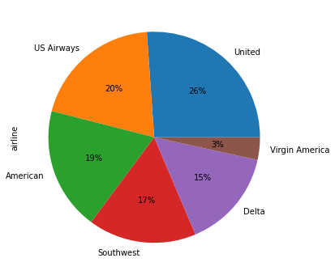

```python
airline_tweets.airline.value_counts().plot(kind='pie', autopct='%1.0f%%')
```

In the output, you can see the percentage of public tweets for each airline. United Airline has the highest number of tweets i.e. 26%, followed by US Airways (20%).

Let's now see the distribution of sentiments across all the tweets.

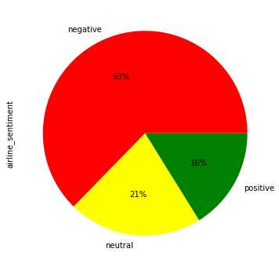

```python
airline_tweets.airline_sentiment.value_counts().plot(kind='pie', autopct='%1.0f%%', colors=["red", "yellow", "green"])
```

From the output, you can see that the majority of the tweets are negative (63%), followed by neutral tweets (21%), and then the positive tweets (16%).

Next, let's see the distribution of sentiment for each individual airline,

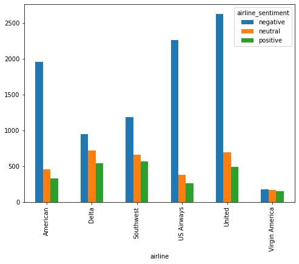

```python
airline_sentiment = airline_tweets.groupby(['airline', 'airline_sentiment']).airline_sentiment.count().unstack()
airline_sentiment.plot(kind='bar')
```

It is evident from the output that for almost all the airlines, the majority of the tweets are negative, followed by neutral and positive tweets. Virgin America is probably the only airline where the ratio of the three sentiments is somewhat similar.

let's use the Seaborn library to view the average confidence level for the tweets belonging to three sentiment categories.

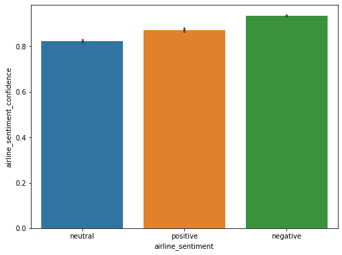

```python
import seaborn as sns

sns.barplot(x='airline_sentiment', y='airline_sentiment_confidence' , data=airline_tweets)
```

From the output, you can see that the confidence level for negative tweets is higher compared to positive and neutral tweets.

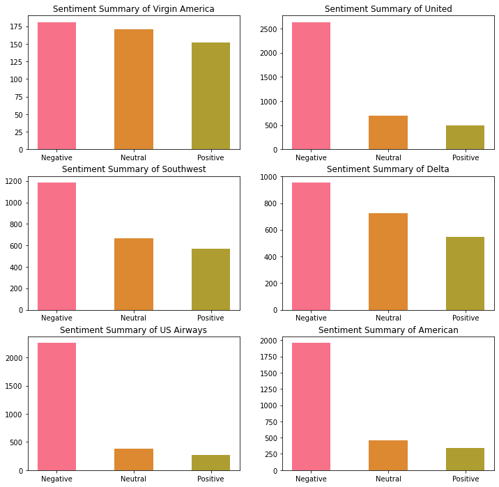

```python
def plot_sub_sentiment(Airline):
    pdf = airline_tweets[airline_tweets['airline']==Airline]
    count = pdf['airline_sentiment'].value_counts()
    Index = [1,2,3]
    color=sns.color_palette("husl", 10)
    plt.bar(Index,count,width=0.5,color=color)
    plt.xticks(Index,['Negative','Neutral','Positive'])
    plt.title('Sentiment Summary of' + " " + Airline)

airline_name = airline_tweets['airline'].unique()
plt.figure(1,figsize=(12,12))
for i in range(6):
    plt.subplot(3,2,i+1)
    plot_sub_sentiment(airline_name[i])
```

```python
#counting the total number of negative reasons
airline_tweets.negativereason.value_counts()
```

```
Customer Service Issue         2910
Late Flight                    1665
Can't Tell                     1190
Cancelled Flight                847
Lost Luggage                    724
Bad Flight                      580
Flight Booking Problems         529
Flight Attendant Complaints     481
longlines                       178
Damaged Luggage                  74
Name: negativereason, dtype: int64
```

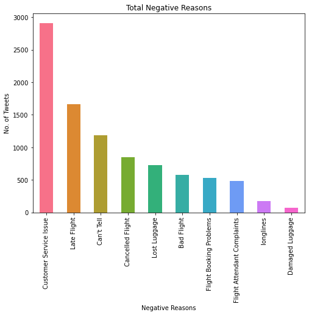

```python
#Plotting all the negative reasons
color=sns.color_palette("husl", 10)
pd.Series(airline_tweets["negativereason"]).value_counts().plot(kind = "bar",
                        color=color,figsize=(8,6),title = "Total Negative Reasons")
plt.xlabel('Negative Reasons', fontsize=10)
plt.ylabel('No. of Tweets', fontsize=10)
```

# Word Cloud for the negative Tweets

```python
from wordcloud import WordCloud,STOPWORDS
```

```python
airline_tweets=airline_tweets [airline_tweets ['airline_sentiment']=='negative']
words = ' '.join(airline_tweets ['text'])
cleaned_word = " ".join([word for word in words.split()
                            if 'http' not in word
                                and not word.startswith('@')
                                and word != 'RT'
                            ])
```

```python
wordcloud = WordCloud(stopwords=STOPWORDS,
                      background_color='black',
                      width=3000,
                      height=2500
                     ).generate(cleaned_word)
```

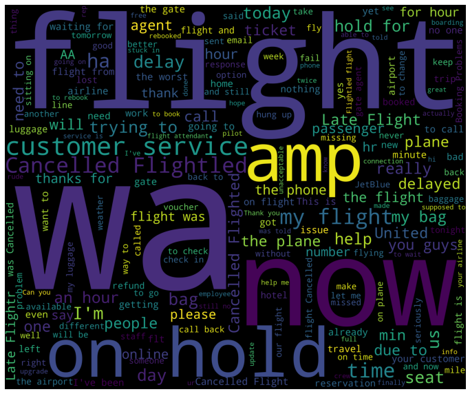

```python
plt.figure(1,figsize=(12, 12))
plt.imshow(wordcloud)
plt.axis('off')
plt.show()
```

# We can find that the Tweets with negative moods are frequently involved some words like cancelled, flight ,customer or hour. People might guess that customer tends to complain when they are waiting for the delayed flights.

# Wordcloud for positive reasons

The code for getting positive sentiments is completely same with the one for negative sentiments. Just replace negative with positive in the first line. Easy, right!

```python
airline_tweets=airline_tweets [airline_tweets ['airline_sentiment']=='positive']
words = ' '.join(airline_tweets ['text'])
cleaned_word = " ".join([word for word in words.split()
                            if 'http' not in word
                                and not word.startswith('@')
                                and word != 'RT'
                            ])
```

```python
wordcloud = WordCloud(stopwords=STOPWORDS,
                      background_color='black',
                      width=3000,
                      height=2500
                     ).generate(cleaned_word)
```

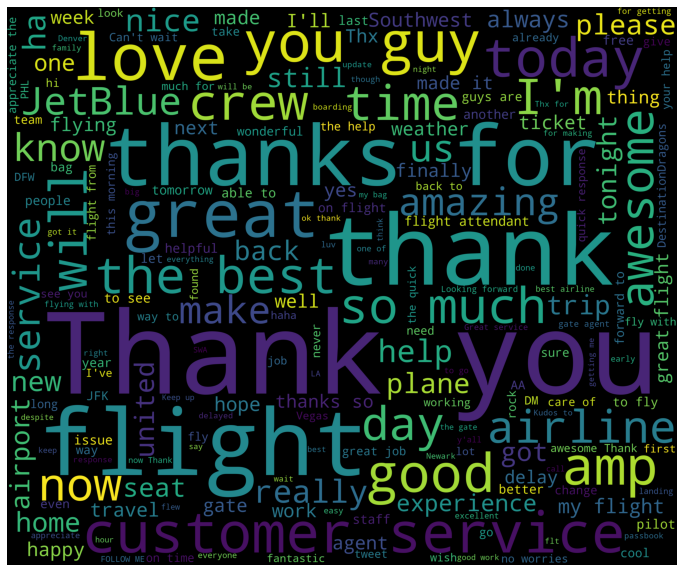

```python
plt.figure(1,figsize=(12, 12))
plt.imshow(wordcloud)
plt.axis('off')
plt.show()
```

```python
# Calculate highest frequency words in positive tweets
def freq(str):

    # break the string into list of words
    str = str.split()
    str2 = []

    # loop till string values present in list str
    for i in str:

        # checking for the duplicacy
        if i not in str2:

            # insert value in str2
            str2.append(i)

    for i in range(0, len(str2)):
        if(str.count(str2[i])>50):
            print('Frequency of', str2[i], 'is :', str.count(str2[i]))

print(freq(cleaned_word))
```

```
Frequency of to is : 923
Frequency of the is : 924
Frequency of time is : 59
Frequency of I is : 574
Frequency of fly is : 54
Frequency of this is : 143
Frequency of :) is : 96
Frequency of it is : 166
Frequency of was is : 226
Frequency of and is : 416
Frequency of an is : 74
Frequency of good is : 75
Frequency of so is : 163
Frequency of much is : 54
Frequency of is is : 219
Frequency of a is : 501
Frequency of great is : 144
Frequency of my is : 320
Frequency of &amp; is : 77
Frequency of on is : 327
Frequency of I'm is : 67
Frequency of flying is : 59
Frequency of your is : 212
Frequency of all is : 92
Frequency of from is : 124
Frequency of Thanks! is : 69
Frequency of for is : 658
Frequency of flight is : 263
Frequency of but is : 91
Frequency of you is : 509
Frequency of would is : 56
Frequency of be is : 135
Frequency of with is : 195
Frequency of you. is : 77
Frequency of love is : 85
Frequency of You is : 62
Frequency of are is : 120
Frequency of of is : 236
Frequency of that is : 102
Frequency of in is : 309
```

[output cut: 17 more lines]

```
Frequency of thanks is : 218
Frequency of get is : 111
Frequency of me is : 196
Frequency of service is : 100
Frequency of you! is : 129
Frequency of Thanks is : 177
Frequency of as is : 57
Frequency of thank is : 204
Frequency of will is : 85
Frequency of our is : 64
Frequency of up is : 66
Frequency of guys is : 76
Frequency of got is : 85
Frequency of made is : 55
None
```

```python
air_senti=pd.crosstab(airline_tweets.airline, airline_tweets.airline_sentiment)
air_senti
```

| airline_sentiment airline | negative | neutral | positive |
| --- | --- | --- | --- |
| American | 1960 | 463 | 336 |
| Delta | 955 | 723 | 544 |
| Southwest | 1186 | 664 | 570 |
| US Airways | 2263 | 381 | 269 |
| United | 2633 | 697 | 492 |
| Virgin America | 181 | 171 | 152 |

```python
percent=air_senti.apply(lambda a: a / a.sum() * 100, axis=1)
percent
```

| airline_sentiment airline | negative | neutral | positive |
| --- | --- | --- | --- |
| American | 71.040232 | 16.781443 | 12.178325 |
| Delta | 42.979298 | 32.538254 | 24.482448 |
| Southwest | 49.008264 | 27.438017 | 23.553719 |
| US Airways | 77.686234 | 13.079300 | 9.234466 |
| United | 68.890633 | 18.236525 | 12.872841 |
| Virgin America | 35.912698 | 33.928571 | 30.158730 |

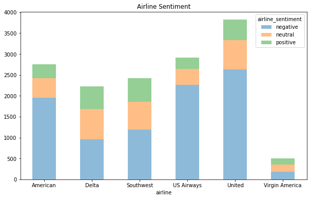

```python
pd.crosstab(index = airline_tweets["airline"],columns = airline_tweets["airline_sentiment"]).plot(kind='bar',
                figsize=(10, 6),alpha=0.5,rot=0,stacked=True,title="Airline Sentiment")
```

**American,US Airways , United have more negative tweets**

```python
airline_tweets['tweet_created'] = pd.to_datetime(airline_tweets['tweet_created'])
airline_tweets["date_created"] = airline_tweets["tweet_created"].dt.date
```

```python
airline_tweets["date_created"]
```

```
0        2015-02-24
1        2015-02-24
2        2015-02-24
3        2015-02-24
4        2015-02-24
            ...
14635    2015-02-22
14636    2015-02-22
14637    2015-02-22
14638    2015-02-22
14639    2015-02-22
Name: date_created, Length: 14640, dtype: object
```

```python
df = airline_tweets.groupby(['date_created','airline'])
df = df.airline_sentiment.value_counts()
df.unstack()
```

| date_created | airline_sentiment airline | negative | neutral | positive |
| --- | --- | --- | --- | --- |
| 2015-02-16 | Delta | 1.0 | 1.0 | NaN |
|  | United | 2.0 | NaN | NaN |
| 2015-02-17 | Delta | 108.0 | 86.0 | 69.0 |
|  | Southwest | 213.0 | 85.0 | 86.0 |
|  | US Airways | 233.0 | 30.0 | 48.0 |
|  | United | 272.0 | 75.0 | 49.0 |
|  | Virgin America | 12.0 | 21.0 | 21.0 |
| 2015-02-18 | American | 1.0 | NaN | NaN |
|  | Delta | 105.0 | 86.0 | 77.0 |
|  | Southwest | 110.0 | 106.0 | 76.0 |
|  | US Airways | 244.0 | 32.0 | 41.0 |
|  | United | 257.0 | 90.0 | 59.0 |
|  | Virgin America | 19.0 | 21.0 | 20.0 |
| 2015-02-19 | American | NaN | NaN | 1.0 |
|  | Delta | 135.0 | 70.0 | 78.0 |
|  | Southwest | 127.0 | 94.0 | 96.0 |
|  | US Airways | 193.0 | 54.0 | 32.0 |
|  | United | 272.0 | 85.0 | 69.0 |
|  | Virgin America | 24.0 | 26.0 | 20.0 |
| 2015-02-20 | American | 1.0 | NaN | NaN |
|  | Delta | 91.0 | 90.0 | 70.0 |
|  | Southwest | 132.0 | 110.0 | 77.0 |
|  | US Airways | 248.0 | 52.0 | 33.0 |
|  | United | 342.0 | 99.0 | 85.0 |
|  | Virgin America | 21.0 | 32.0 | 17.0 |
| 2015-02-21 | American | 1.0 | NaN | NaN |
|  | Delta | 98.0 | 79.0 | 66.0 |
|  | Southwest | 257.0 | 60.0 | 53.0 |
|  | US Airways | 291.0 | 39.0 | 30.0 |
|  | United | 365.0 | 88.0 | 53.0 |
|  | Virgin America | 37.0 | 12.0 | 28.0 |
| 2015-02-22 | American | 762.0 | 132.0 | 94.0 |
|  | Delta | 255.0 | 76.0 | 77.0 |
|  | Southwest | 129.0 | 77.0 | 73.0 |
|  | US Airways | 561.0 | 60.0 | 27.0 |
|  | United | 532.0 | 102.0 | 69.0 |
|  | Virgin America | 27.0 | 16.0 | 10.0 |
| 2015-02-23 | American | 826.0 | 178.0 | 137.0 |
|  | Delta | 125.0 | 195.0 | 71.0 |
|  | Southwest | 116.0 | 83.0 | 77.0 |
|  | US Airways | 372.0 | 74.0 | 42.0 |
|  | United | 449.0 | 109.0 | 83.0 |
|  | Virgin America | 31.0 | 37.0 | 23.0 |
| 2015-02-24 | American | 369.0 | 153.0 | 104.0 |
|  | Delta | 37.0 | 40.0 | 36.0 |
|  | Southwest | 102.0 | 49.0 | 32.0 |
|  | US Airways | 121.0 | 40.0 | 16.0 |
|  | United | 142.0 | 49.0 | 25.0 |
|  | Virgin America | 10.0 | 6.0 | 13.0 |

# Data Cleaning

Tweets contain many slang words and punctuation marks. We need to clean our tweets before they can be used for training the machine learning model. However, before cleaning the tweets, let's divide our dataset into feature and label sets.

Our feature set will consist of tweets only. If we look at our dataset, the 11th column contains the tweet text. Note that the index of the column will be 10 since pandas columns follow zero-based indexing scheme where the first column is called 0th column. Our label set will consist of the sentiment of the tweet that we have to predict. The sentiment of the tweet is in the second column (index 1). To create a feature and a label set, we can use the iloc method off the pandas data frame.

```python
features = airline_tweets.iloc[:, 10].values
labels = airline_tweets.iloc[:, 1].values
```

```python
features
```

```
array(['@VirginAmerica What @dhepburn said.',
       "@VirginAmerica plus you've added commercials to the experience... tacky.",
       "@VirginAmerica I didn't today... Must mean I need to take another trip!",
       ...,
       '@AmericanAir Please bring American Airlines to #BlackBerry10',
       "@AmericanAir you have my money, you change my flight, and don't answer your phones! Any other suggestions so I can make my commitment??",
       '@AmericanAir we have 8 ppl so we need 2 know how many seats are on the next flight. Plz put us on standby for 4 people on the next flight?'],
      dtype=object)
```

```python
labels
```

```
array(['neutral', 'positive', 'neutral', ..., 'neutral', 'negative',
       'neutral'], dtype=object)
```

Once we divide the data into features and training set, we can preprocess data in order to clean it. To do so, we will use regular expressions.

```python
processed_features = []

for sentence in range(0, len(features)):
    # Remove all the special characters
    processed_feature = re.sub(r'\W', ' ', str(features[sentence]))

    # remove all single characters
    processed_feature= re.sub(r'\s+[a-zA-Z]\s+', ' ', processed_feature)

    # Remove single characters from the start
    processed_feature = re.sub(r'\^[a-zA-Z]\s+', ' ', processed_feature)

    # Substituting multiple spaces with single space
    processed_feature = re.sub(r'\s+', ' ', processed_feature, flags=re.I)

    # Removing prefixed 'b'
    processed_feature = re.sub(r'^b\s+', '', processed_feature)

    # Converting to Lowercase
    processed_feature = processed_feature.lower()

    processed_features.append(processed_feature)
```

```python
processed_features
```

[output not shown]

[output cut: 946 more lines]

```
 ' southwestair thanks for the opportunity ',
 ' southwestair truly the best in customerservice if something goes wrong no matter how big or small the issue was they fix it thank you',
 ' southwestair you are the easiest airline to deal with loveeee you so much',
 ' southwestair thank you ',
 ' southwestair ok gotcha ',
 ' southwestair m excited too but perhaps you could scale your excitement back by few weeks ',
 ' southwestair me amp sammi_jon3s are best friends because of imaginedragons any chance we could get tickets to destinationdragons ',
 ' southwestair thank you you guys ',
 ' southwestair ceo gary kelly we are america most loved and most flown airline southwestrally bwi bestemployees swaculture swapic',
 ' southwestair dresparkles thank you finally made it to my destination',
 ' southwestair luvin me some flights today don change and please add paypal as payment option ',
 ' southwestair makes flying for uno_baseball fun flight crew just led the plane in singing happy birthday to one of our guys luvintheair',
 ' southwestair just received your birthday card it was amazing and made me smile with joy nice videos thanks ',
 'thanks southwestair heartlanta',
 ...]
```

# Representing Text in Numeric Form

To make statistical algorithms work with text, we first have to convert text to numbers. To do so, three main approaches exist i.e. Bag of Words, TF-IDF and Word2Vec.

# TF-IDF

In the bag of words approach, each word has the same weight. The idea behind the TF-IDF approach is that the words that occur less in all the documents and more in individual document contribute more towards classification.

TF-IDF is a combination of two terms. Term frequency and Inverse Document frequency. They can be calculated as:

TF = (Frequency of a word in the document)/(Total words in the document) IDF = Log((Total number of docs)/(Number of docs containing the word))

```python
nltk.download('stopwords')
from nltk.corpus import stopwords
from sklearn.feature_extraction.text import TfidfVectorizer

vectorizer = TfidfVectorizer (max_features=2500, min_df=7, max_df=0.8, stop_words=stopwords.words('english'))
processed_features = vectorizer.fit_transform(processed_features).toarray()
```

```python
processed_features
```

```
array([[0., 0., 0., ..., 0., 0., 0.],
       [0., 0., 0., ..., 0., 0., 0.],
       [0., 0., 0., ..., 0., 0., 0.],
       ...,
       [0., 0., 0., ..., 0., 0., 0.],
       [0., 0., 0., ..., 0., 0., 0.],
       [0., 0., 0., ..., 0., 0., 0.]])
```

In the code above, we define that the max_features should be 2500, which means that it only uses the 2500 most frequently occurring words to create a bag of words feature vector. Words that occur less frequently are not very useful for classification.

Similarly, max_df specifies that only use those words that occur in a maximum of 80% of the documents. Words that occur in all documents are too common and are not very useful for classification. Similarly, min-df is set to 7 which shows that include words that occur in at least 7 documents.

# Dividing Data into Training and Test Sets

n the previous section, we converted the data into the numeric form. As the last step before we train our algorithms, we need to divide our data into training and testing sets. The training set will be used to train the algorithm while the test set will be used to evaluate the performance of the machine learning model.

```python
from sklearn.model_selection import train_test_split

X_train, X_test, y_train, y_test = train_test_split(processed_features, labels, test_size=0.2, random_state=0)
```

# Training the Model

Once data is split into training and test set, machine learning algorithms can be used to learn from the training data. The sklearn.ensemble module contains the RandomForestClassifier class that can be used to train the machine learning model using the random forest algorithm. To do so, we need to call the fit method on the RandomForestClassifier class and pass it our training features and labels, as parameters.

```python
from sklearn.ensemble import RandomForestClassifier

text_classifier = RandomForestClassifier(n_estimators=200, random_state=0)
text_classifier.fit(X_train, y_train)
```

```
RandomForestClassifier(bootstrap=True, ccp_alpha=0.0, class_weight=None,
                       criterion='gini', max_depth=None, max_features='auto',
                       max_leaf_nodes=None, max_samples=None,
                       min_impurity_decrease=0.0, min_impurity_split=None,
                       min_samples_leaf=1, min_samples_split=2,
                       min_weight_fraction_leaf=0.0, n_estimators=200,
                       n_jobs=None, oob_score=False, random_state=0, verbose=0,
                       warm_start=False)
```

# Making Predictions and Evaluating the Model

The last step is to make predictions on the model. To do so, we need to call the predict method on the object of the RandomForestClassifier class that we used for training.

```python
predictions = text_classifier.predict(X_test)
```

To evaluate the performance of the machine learning models, we can use classification metrics such as a confusion metrix, F1 measure, accuracy, etc.

```python
from sklearn.metrics import classification_report, confusion_matrix, accuracy_score

print(confusion_matrix(y_test,predictions))
print(classification_report(y_test,predictions))
print(accuracy_score(y_test, predictions))
```

```
[[1723  108   39]
 [ 326  248   40]
 [ 132   58  254]]
              precision    recall  f1-score   support

    negative       0.79      0.92      0.85      1870
     neutral       0.60      0.40      0.48       614
    positive       0.76      0.57      0.65       444

    accuracy                           0.76      2928
   macro avg       0.72      0.63      0.66      2928
weighted avg       0.75      0.76      0.74      2928

0.7599043715846995
```

# KNN ALGO

```python
from sklearn.neighbors import KNeighborsClassifier
text_classifier2 = KNeighborsClassifier(n_neighbors = 5)#no of neighbors is hpyer parameter
text_classifier2.fit(X_train, y_train)
```

```
KNeighborsClassifier(algorithm='auto', leaf_size=30, metric='minkowski',
                     metric_params=None, n_jobs=None, n_neighbors=5, p=2,
                     weights='uniform')
```

```python
predictions2 = text_classifier2.predict(X_test)
```

```python
from sklearn.metrics import classification_report, confusion_matrix, accuracy_score

print(confusion_matrix(y_test,predictions2))
print(classification_report(y_test,predictions2))
print(accuracy_score(y_test, predictions2))
```

```
[[1500  316   54]
 [ 252  310   52]
 [ 118  103  223]]
              precision    recall  f1-score   support

    negative       0.80      0.80      0.80      1870
     neutral       0.43      0.50      0.46       614
    positive       0.68      0.50      0.58       444

    accuracy                           0.69      2928
   macro avg       0.64      0.60      0.61      2928
weighted avg       0.70      0.69      0.70      2928

0.6943306010928961
```

# Logistic Regression

```python
from sklearn.linear_model import LogisticRegression
model =LogisticRegression()
```

```python
model.fit(X_train, y_train)
```

```
LogisticRegression(C=1.0, class_weight=None, dual=False, fit_intercept=True,
                   intercept_scaling=1, l1_ratio=None, max_iter=100,
                   multi_class='auto', n_jobs=None, penalty='l2',
                   random_state=None, solver='lbfgs', tol=0.0001, verbose=0,
                   warm_start=False)
```

```python
predictions3 = model.predict(X_test)
```

```python
from sklearn.metrics import classification_report, confusion_matrix, accuracy_score

print(confusion_matrix(y_test,predictions3))
print(classification_report(y_test,predictions3))
print(accuracy_score(y_test, predictions3))
```

```
[[1732  115   23]
 [ 268  304   42]
 [ 118   54  272]]
              precision    recall  f1-score   support

    negative       0.82      0.93      0.87      1870
     neutral       0.64      0.50      0.56       614
    positive       0.81      0.61      0.70       444

    accuracy                           0.79      2928
   macro avg       0.76      0.68      0.71      2928
weighted avg       0.78      0.79      0.78      2928

0.7882513661202186
```

# Decision Tree Algorithim

```python
from sklearn.tree import DecisionTreeClassifier
model3= DecisionTreeClassifier(criterion="gini")
#here we are facing the problem of overfitting
#train the model
model3.fit(X_train, y_train)
```

```
DecisionTreeClassifier(ccp_alpha=0.0, class_weight=None, criterion='gini',
                       max_depth=None, max_features=None, max_leaf_nodes=None,
                       min_impurity_decrease=0.0, min_impurity_split=None,
                       min_samples_leaf=1, min_samples_split=2,
                       min_weight_fraction_leaf=0.0, presort='deprecated',
                       random_state=None, splitter='best')
```

```python
predictions4 = model3.predict(X_test)
```

```python
from sklearn.metrics import classification_report, confusion_matrix, accuracy_score

print(confusion_matrix(y_test,predictions4))
print(classification_report(y_test,predictions4))
print(accuracy_score(y_test, predictions4))
```

```
[[1434  312  124]
 [ 268  285   61]
 [ 121   82  241]]
              precision    recall  f1-score   support

    negative       0.79      0.77      0.78      1870
     neutral       0.42      0.46      0.44       614
    positive       0.57      0.54      0.55       444

    accuracy                           0.67      2928
   macro avg       0.59      0.59      0.59      2928
weighted avg       0.68      0.67      0.67      2928

0.6693989071038251
```